# Lab 4: Avocado Prices and Cost of Living in California

- Show All Code
- Hide All Code
- View Source

Author

Rachel Friesen

## Challenge

> Find or make a dataset with house prices for these four California regions. Join this dataset with your California avocado dataset. Use your new joined dataset to make an argument about the relationship between house prices and avocado prices/sales. Support your argument with a plot.

> *The house prices in California are incredibly high, especially in these metropolitan areas. I calculated the total cost of eating an avocado a day in each of these cities over a three year time frame (roughly the number of years with available avocado cost data). I then compared this value to the cost of making a down payment in 2023 on a house in each respective region. The cost of a down payment on a house is vastly greater than the cumulative cost of an avocado habit. Thus, the mismatch between house prices and the ability of millenials to purchase homes is a much larger issue than millennials’ penchants for avocado toast.*

> **Note: Revised 2/16/2023 to change from bar plot to Cleveland Dot Plot**

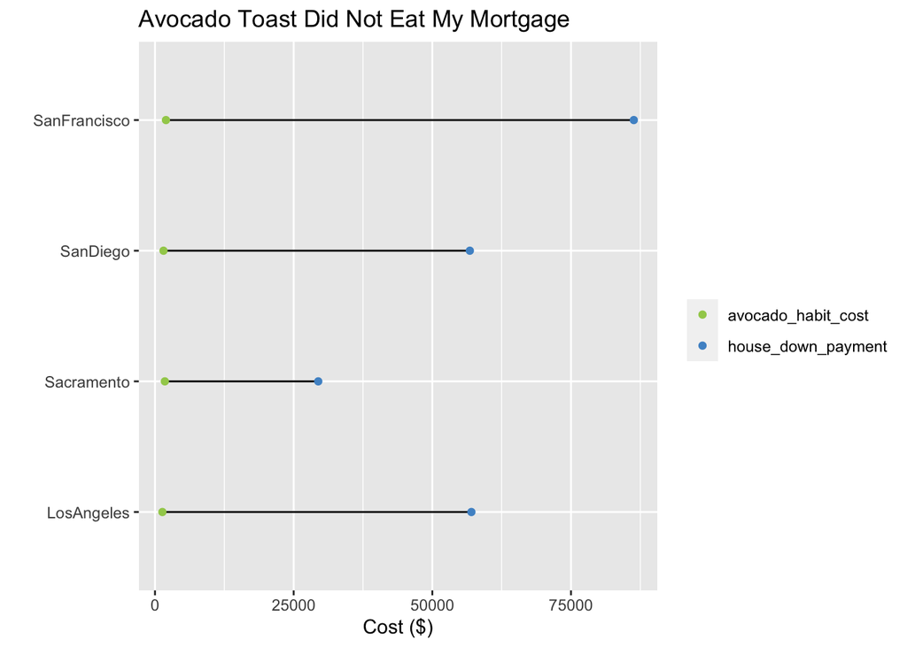

```r
# load libraries
library(tidyverse)
library(here)

# read in data
avocado <- read_csv(here('labs', 'lab_4', 'avocado.csv'))

# create data frame with current median home prices for major CA cities
# source: https://www.zillow.com/home-values/102001/united-states/
home_price <- data.frame (region = c("LosAngeles", "Sacramento", "SanDiego", "SanFrancisco"),
                          median_price = c(950715, 490537, 946026, 1438754))

# calculate columns and reshape data
# source: https://www.rocketmortgage.com/learn/what-is-the-average-down-payment-on-a-house
avocado_clean_chal <- avocado %>%
  group_by(region) %>%
  summarize(mean = mean(AveragePrice)) %>%
  mutate(avocado_habit_cost = mean*365*3) %>%
  inner_join(y = home_price, by = "region") %>%
  mutate(house_down_payment = median_price*.06) %>%
  pivot_longer(cols = c("avocado_habit_cost", "house_down_payment"),
               names_to = "cost_type",
               values_to = "value")


# plot data
# source: https://uc-r.github.io/cleveland-dot-plots
ggplot(data = avocado_clean_chal,
       mapping = aes(y = region,
                     x = value)) +
  geom_line(aes(group = region)) +
  geom_point(aes(color = cost_type)) +
  labs(title = "Avocado Toast Did Not Eat My Mortgage",
       x = "Cost ($)",
       y = "",
       color = "") +
  scale_color_manual(values = c("darkolivegreen3", "steelblue3"))
```